# Red Wine Quality by Eric Ambriza

## 3.3 - Alcohol, pH Levels & Volatile Acidity

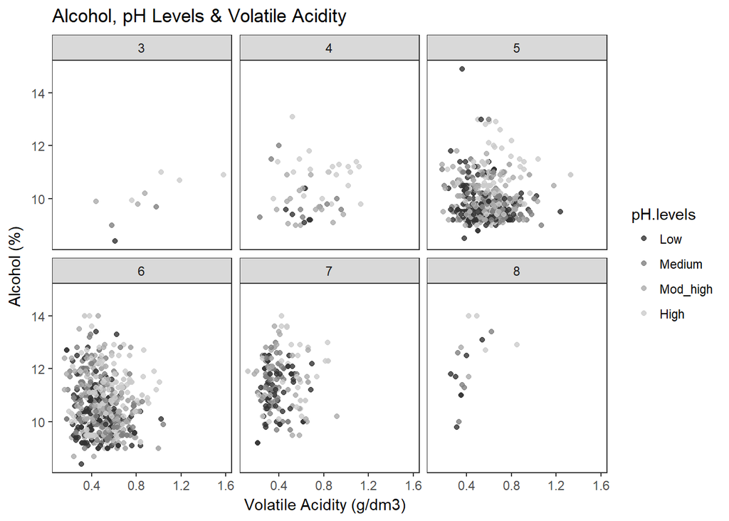

```
##
##     Low Medium Mod_high High
##   3   1      2        3    4
##   4   6     11       16   20
##   5 193    173      154  161
##   6 158    150      168  162
##   7  59     57       47   36
##   8   7      5        2    4
```

##### In this case the pH seems to be low on the best quality and the opposite happens for the worst wines. That confirm our early conlusion were we could see that low pH gives more space for a better citric acidity making the wine more fresh and with that a better quality.

## 3.4 - Alcohol levels, Density & Volatitle Acidity

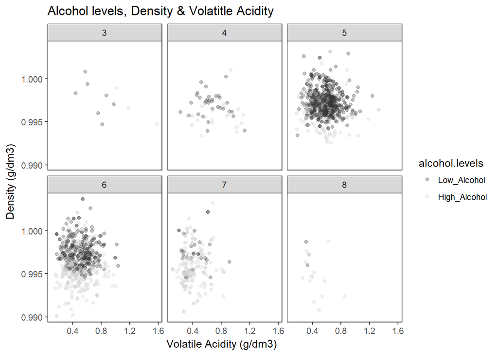

##### Confirming what we saw, the low density gives more room to increase the probability of having a high rate of alcohol along side with the Volatile.acidity this can the proof this strong correlation of this variables wich can improve the wine quality.

## 3.5 - Volatile and Fixed Acidity & Citric Acid

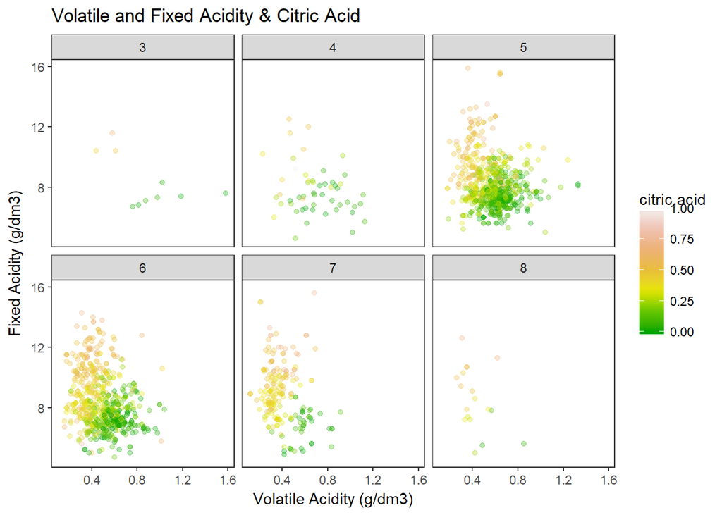

##### Plotting all acids we can get a better visibility on how they work together. Wich we can describe the best quality being populated by concentration of citric acid giving the wine a better taste and smell. The Volatile acidity remain the same following the rule of the best quality being followed by the low rates. But the trickiest part is that the fixed acidity doesnt seem to change that much on the quality were can be easly noticed that the all type of wines following the same distribuiton.

## 3.6 - Free and Total Sulfur Dioxide & Sulphacates

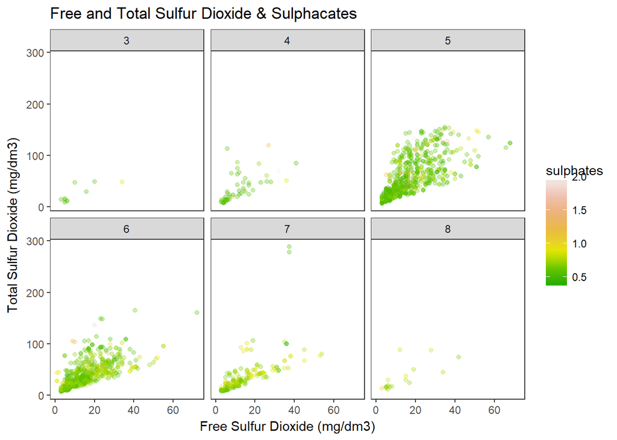

##### The sulfurs follow the same trend when it comes to total and free sulfur dioxide were both appeared positive and strong correlated, however the high concentration of sulphates are more prensent on the best quality, Wich make sense since works as an antimicrobial and antioxidant making the wine more valuable.

# Multivariate Analysis

##### In this section the investigations lead me to get a deeper undertsanting of the data were i could conclude:

##### pH have low concentration on the best wines. Due to the fact that pH gives more space for a better citric acidity making the wine more fresh and with that a better quality.

##### Low density gives more room to increase the probability of having a high rate of alcohol along side with the volatile.acidity making the wine tastefull.

##### The total and free sulfur dioxide were both appeared positive and strong correlated, however the high concentration of sulphates are more prensent on the best quality, Wich make sense since works as an antimicrobial and antioxidant making the wine more valuable.

##### Find a surprice with sugar concentration were from the bivariate anaylsis the conclusion wasnt matching when i also decided to create a new categorical variable to a better understanding. Was easy to find out that on the quality 3 comparing with 8, we can see that the same portion of low sugar appear in both distribuitions. That way the possibility of the fermentation be the cause of the reduce of sugar concentration was false.

# Final Plots and Summary

### Plot One

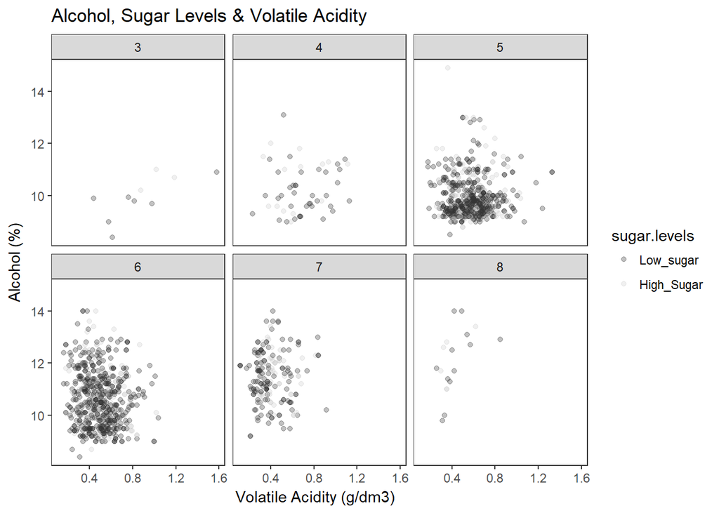

### Description One

##### Both high and low sugar distribuited at the same way, however more points of high sugar can be seen on good wines (quality 7 and 8). High percentage of alcohol are matching as it grows on quality classification, followed by the Volacity Acidity were the beehavior is the opposite as the alcohol were the lower rates of concentration can be found on the best wines.

### Plot Two

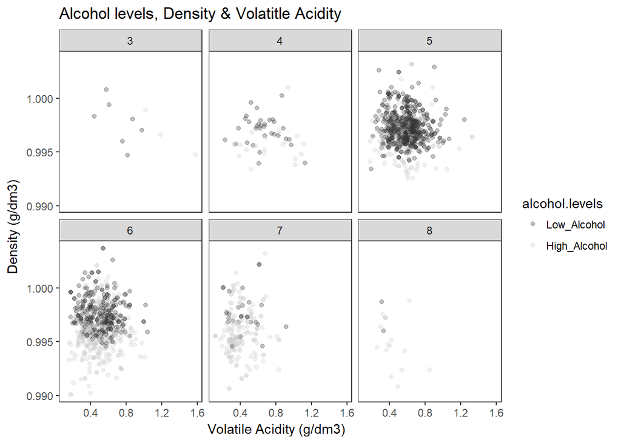

### Description Two

##### Besides the worst wines (3 and 4) the lower concentration of density are cleary matching with wines with more alcohol. Making this way density a variable important even not being strongly correlated with quality.

### Plot Three

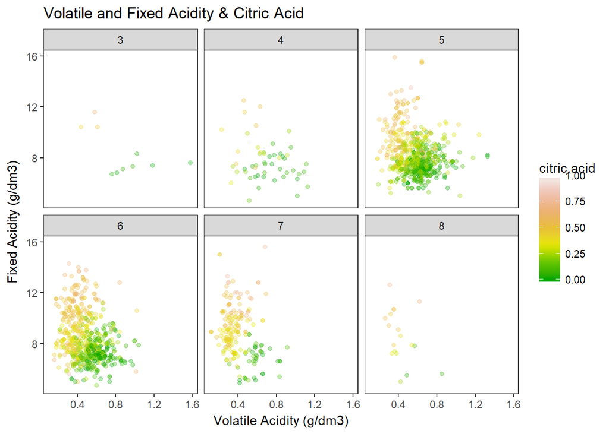

### Description Three

##### The plots tend to be more green on the lower qualitites comparing with the followed ones, despite the fact that the fixed acidity behave almost the same on all wine types. The citric acid and volatile acidity which can influence on the taste are distribuited according to this finding were you can find high levels of citric acid and low levels of Volatile on the best quality of wine.

# Reflection

##### Was very interest exploring this data, the first part was tricky because an initial prediction was changed after further analysis were i can nut shell here describing what the variables found important to a wine receive a good or bad quality review :

##### - If a wine has high percentage of alcohol its most likely to have a good rate.

##### - Acids:

##### The fixed acidity was a bit tricky because the correlation coeficiente is positive so my first assumptions was that the good quality wines would tend to have a slight high concentration compared with the wines with the bad quality. However the plots has shown that for all qualities of wine the fixed acidity seems to have the same range.

##### Citric Acid: Despite i didnt found that directly that fixed acidity is important have a good quality wine, i could noticed that the wines with high concentration of fixid acidity tend to have a high citric acid concentration, which is good for a wine thanks to the fact that can add ‘freshness’ and flavor to wines.

##### Volatile Acidity: Found this variable important to the quality of wine since high concentrations can give the wine a taste and smell like vinager. Taking a brief look on the last plot, its easy to see that for the quality 8 only 1 wine is greater than 0.8 g/dm3, on quality 7 only 4, and that tend to increase until the quality 3 were basicly half of the wines is less than 0.8 g/dm3 of volatile acidity.

##### - Found the sulphates relevant due to the fact that high concentrations of them are more frequent as it grows in wine quality, thats because the sulphate can act as an antimicrobial and antioxidant.

##### - Even findind the residual sugar almost distribuited that same way among the wines, we can notice an high level of concentration on the wines rated with good quality which leads us to conclude that sufar is also important to have a good wine.

##### - pH gives more space for a better citric acidity making the wine more fresh and with that a better quality.

##### - Found density with a similiar behavior has like the fixed acidity since the low density gives more room to increase the probability of having a high rate of alcohol.

##### Speaking on the struggles wich i also think that this could be an improvement on a future analyse on this type of data set. The fact that wine with low and high rates are few on the data set comparing with wines with medium quality. I believe that if the numbers of the wine in data set was balanced in numbers of all types of quality wines it would be much clear for a better and precise.

##### Wonder to know how the wines were tested, cleary i believe that theres mechanism to measure the substances but to rate the taste that should be given to a person. if he tested many in a raw that can also bias the tests.

##### Its common to find cases were well settled brands have an favoritism so would be much better if the data set had the brands name attached.

##### The most dificult step were the multivariate plots, since i wanted to find the best way to put together the acids and sulfur. Went trought many tutorials and also books until i find a way to cleary see the plots and have a conlusion from it.